# SpotiViz

Nikhil Rajkumar & Meghana Jaladanki

4/19/2021

## SpotiViz

We intend on using a Spotify dataset to produce effective visualizations that answer a specific set of questions. Our dataset consists of song information and it consists of a bunch of musical attributes along with a track name. We have immense data to locate trends and how music has progressed over time. With attributes ranging from liveness, popularity, danceability, speechiness, energy, etc.

```r
df.spotify <- read.csv("data.csv")
df.spotify$explicit <- as.factor(df.spotify$explicit)
df.spotify$duration_ms <- (df.spotify$duration_ms/1000)
summary(df.spotify)
```

```
##   acousticness      artists           danceability     duration_ms
##  Min.   :0.0000   Length:174389      Min.   :0.0000   Min.   :   4.937
##  1st Qu.:0.0877   Class :character   1st Qu.:0.4140   1st Qu.: 166.133
##  Median :0.5170   Mode  :character   Median :0.5480   Median : 205.787
##  Mean   :0.4992                      Mean   :0.5368   Mean   : 232.810
##  3rd Qu.:0.8950                      3rd Qu.:0.6690   3rd Qu.: 265.720
##  Max.   :0.9960                      Max.   :0.9880   Max.   :5338.302
##      energy       explicit        id            instrumentalness
##  Min.   :0.0000   0:162507   Length:174389      Min.   :0.000000
##  1st Qu.:0.2490   1: 11882   Class :character   1st Qu.:0.000000
##  Median :0.4650              Mode  :character   Median :0.000524
##  Mean   :0.4827                                 Mean   :0.197252
##  3rd Qu.:0.7110                                 3rd Qu.:0.252000
##  Max.   :1.0000                                 Max.   :1.000000
##       key            liveness         loudness            mode
##  Min.   : 0.000   Min.   :0.0000   Min.   :-60.000   Min.   :0.0000
##  1st Qu.: 2.000   1st Qu.:0.0992   1st Qu.:-14.908   1st Qu.:0.0000
##  Median : 5.000   Median :0.1380   Median :-10.836   Median :1.0000
##  Mean   : 5.205   Mean   :0.2111   Mean   :-11.751   Mean   :0.7024
##  3rd Qu.: 8.000   3rd Qu.:0.2700   3rd Qu.: -7.499   3rd Qu.:1.0000
##  Max.   :11.000   Max.   :1.0000   Max.   :  3.855   Max.   :1.0000
##      name             popularity     release_date        speechiness
##  Length:174389      Min.   :  0.00   Length:174389      Min.   :0.0000
##  Class :character   1st Qu.:  1.00   Class :character   1st Qu.:0.0352
##  Mode  :character   Median : 25.00   Mode  :character   Median :0.0455
##                     Mean   : 25.69                      Mean   :0.1057
##                     3rd Qu.: 42.00                      3rd Qu.:0.0763
##                     Max.   :100.00                      Max.   :0.9710
##      tempo           valence            year
##  Min.   :  0.00   Min.   :0.0000   Min.   :1920
##  1st Qu.: 93.93   1st Qu.:0.3110   1st Qu.:1955
##  Median :115.82   Median :0.5360   Median :1977
##  Mean   :117.01   Mean   :0.5245   Mean   :1977
##  3rd Qu.:135.01   3rd Qu.:0.7430   3rd Qu.:1999
##  Max.   :243.51   Max.   :1.0000   Max.   :2021
```

# Trends

## 1. How has Popularity of a song varied over time?

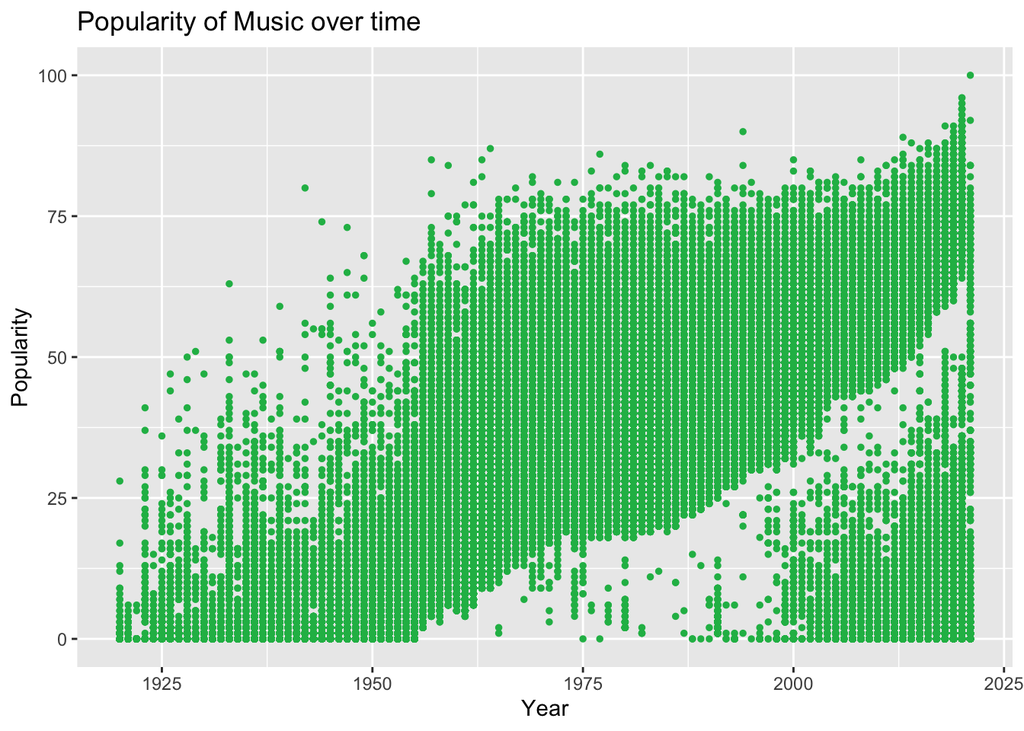

```r
pop.plot <- ggplot(data=df.spotify , aes(x=year, y=popularity)) +
    geom_point(color = "#1DB954", size = 1) +
    ggtitle("Popularity of Music over time") +
    xlab("Year") +
    ylab("Popularity")
pop.plot
```

> This plot explains how newer songs are more popular among Spotify users. This could be explained by how majority of its users (55%) are within the age range of 18-34 and are more likely exposed to newer music and hence the higher popularity.

## 2. How has Danceability of a song varied over time?

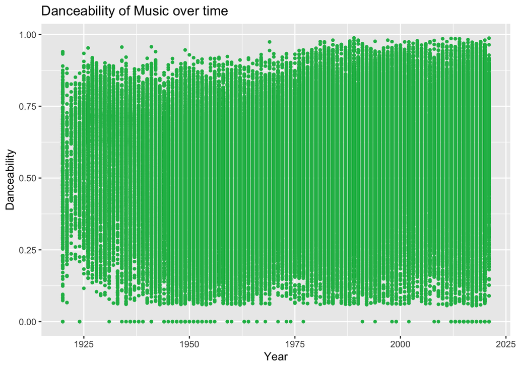

```r
dance.plot <- ggplot(data=df.spotify , aes(x=year, y=danceability)) +
    geom_point(color = "#1DB954", size = 1) +
    ggtitle("Danceability of Music over time") +
    xlab("Year") +
    ylab("Danceability")
dance.plot
```

> There does not seem to be any variation of the danceability of songs over time.

## 3. How has the Popularity of Explicit Language songs changed over time?

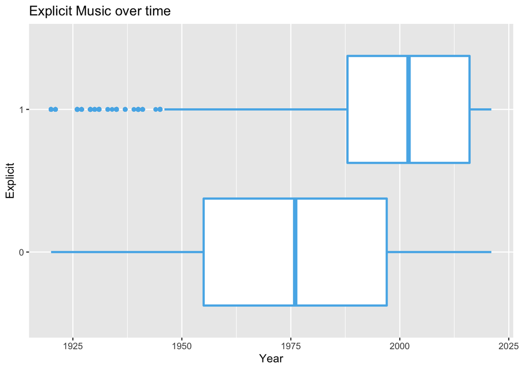

```r
exp.plot <- ggplot(data=df.spotify , aes(x=year, y=explicit)) +
    geom_boxplot(color = "#56B4E9", size = 1) +
    ggtitle("Explicit Music over time") +
    xlab("Year") +
    ylab("Explicit")
exp.plot
```

> 1 represents if a song contains explicit language while 0 conveys that it does not have explicit language. According to the boxplot above, we notice that most of the songs without explicit langauge were released between the late 1950s and late 1990s. However, most of the songs with explicit language were released between the Late 1980s and present day. This could potentially be explained by how society has become more open-minded and progressive over time by being more accepting of artists expressing themselves in music and how they really feel (Hence, the explicit language).

## 4. How has the Duration of a song changed over time?

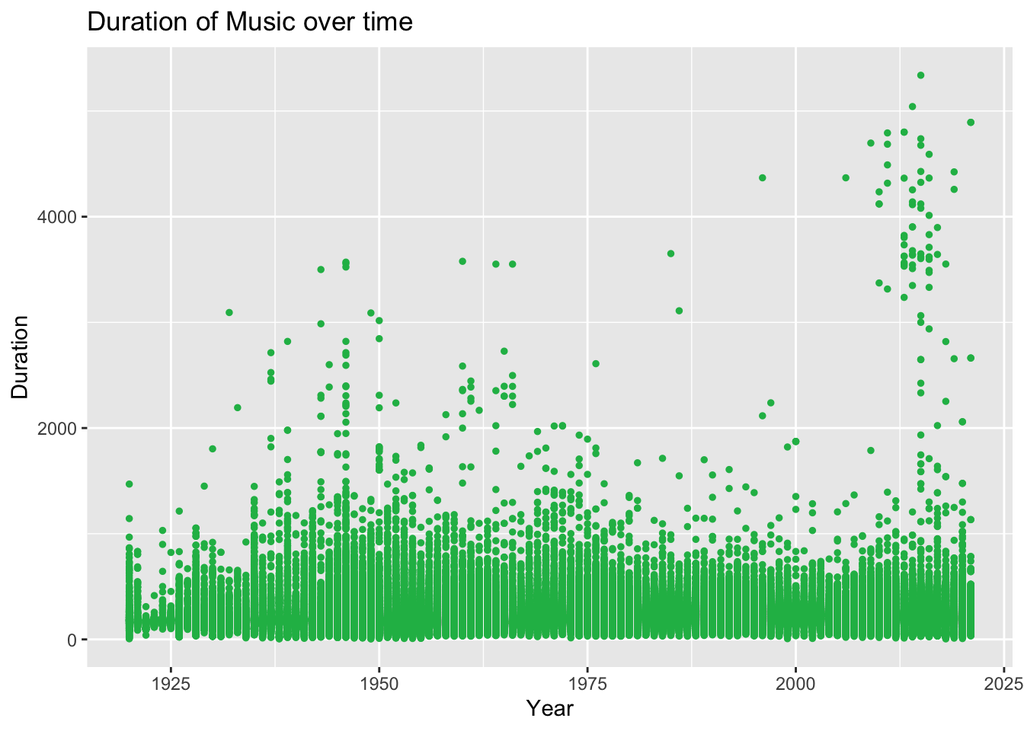

```r
dur.plot <- ggplot(data=df.spotify , aes(x=year, y=duration_ms)) +
    geom_point(color = "#1DB954", size = 1) +
    ggtitle("Duration of Music over time") +
    xlab("Year") +
    ylab("Duration")
dur.plot
```

> There does not seem to be any significant change in trend for the duration of music over time based on the visual.

## 5. How has the Number of Artists on a song varied over time?

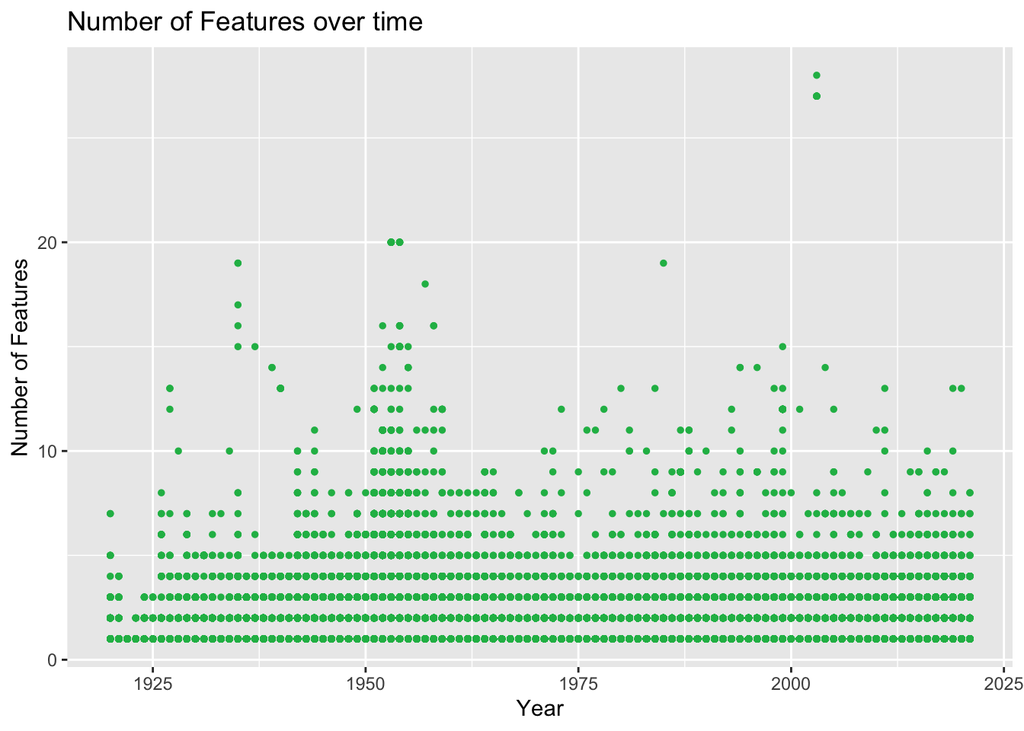

```r
v <- list()

for (i in 1:length(df.spotify$artists)){
    v[i] <- length(strsplit(df.spotify$artists[i], ",")[[1]])
}

df.spotify$art <- v

feat.plot <- ggplot(data=df.spotify , aes(x=year, y=as.numeric(art))) +
    geom_point(color = "#1DB954", size = 1) +
    ggtitle("Number of Features over time") +
    xlab("Year") +
    ylab("Number of Features")
feat.plot
```

> There is no significant trend observed for the number of artists featured over time. With exceptions in the 1950s.

## 6. How has the Number of Artists Featured affect the Popularity of a track?

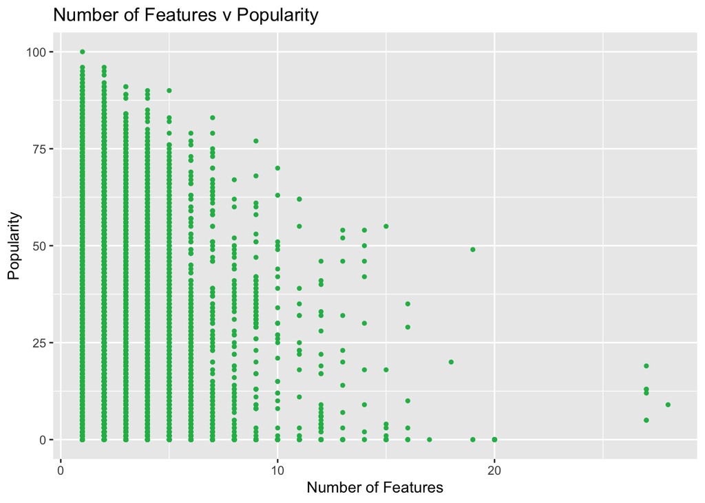

```r
featpop.plot <- ggplot(data=df.spotify , aes(x=as.numeric(art), y=popularity)) +
    geom_point(color = "#1DB954", size = 1) +
    ggtitle("Number of Features v Popularity") +
    ylab("Popularity") +
    xlab("Number of Features")
featpop.plot
```

> This plot shows us that the more artists that feature on a song could lead to lower popularity. However the number of songs that are with many (>10) artists are very few and hence a strong conclusion cannot be drawn from this visualization.

## 7. How does Liveliness vary with Popularity of a track?

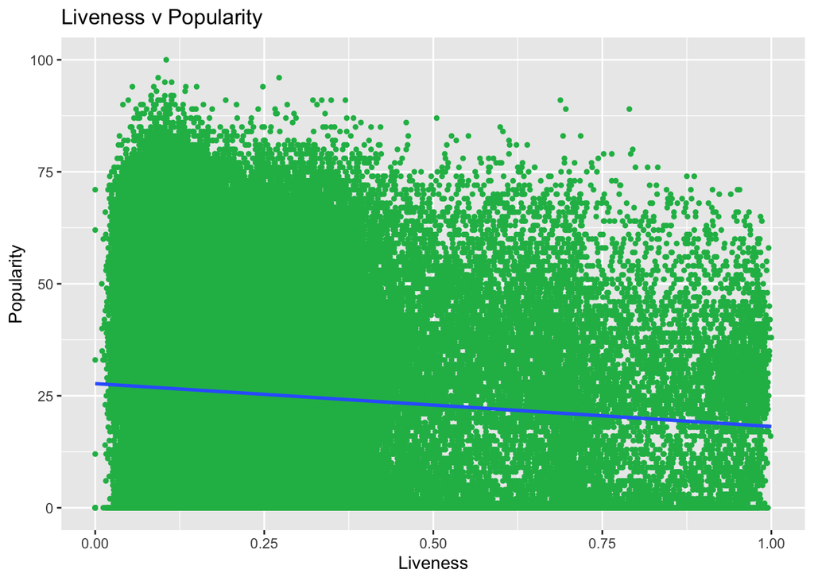

```r
liv.plot <- ggplot(data=df.spotify , aes(x=liveness, y=popularity)) +
    geom_point(color = "#1DB954", size = 1) +
    ggtitle("Liveness v Popularity") +
    xlab("Liveness") +
    ylab("Popularity") +
    geom_smooth(method=lm)
liv.plot
```

> The graph depicts a negative relationship between popularity and liveliness of a good amount of songs, meaning that as the liveliness increases there is also a chance that popularity may also decrease.

## 8. how does Danceability vary with Popularity of a track?

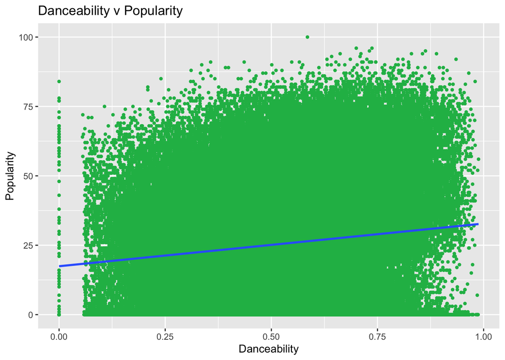

```r
dnce.plot <- ggplot(data=df.spotify , aes(x=danceability, y=popularity)) +
    geom_point(color = "#1DB954", size = 1) +
    ggtitle("Danceability v Popularity") +
    xlab("Danceability") +
    ylab("Popularity") +
    geom_smooth(method=lm)
dnce.plot
```

> The visual shows a small trend of how the more danceable a track is the more popular it might be.

## 9. How does Danceability vary with the Energy of a track?

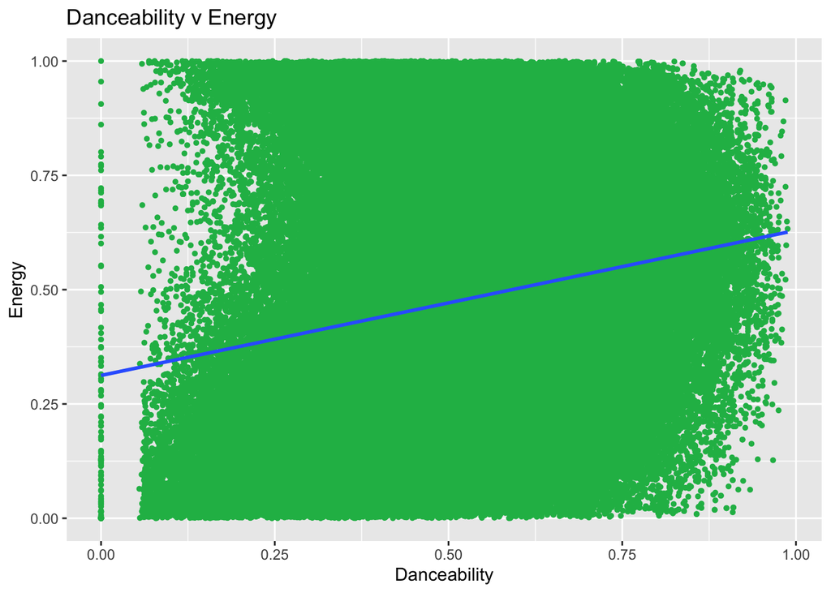

```r
DE.plot <- ggplot(data=df.spotify , aes(x=danceability, y=energy)) +
    geom_point(color = "#1DB954", size = 1) +
    ggtitle("Danceability v Energy") +
    xlab("Danceability") +
    ylab("Energy") +
    geom_smooth(method=lm)
DE.plot
```

### Conclusion:

Given the visuals we have created for this analysis, we can determine that the newer a song, the more popular it is among Spotify users. Furthermore, that non-explicit language songs were released in the late 1950’s and late 1990’s, whereas the explicit language songs were released in the late 1980’s and present day. Other trends observed is that as the liveliness increases there is also a chance that popularity may also decrease and that more danceable tracks are more popular. Lastly, we were able to visualize that with increasing energy there is also increasing danceability with the songs from this dataset. Not all of our graphs showed trends. We did not observe any trends for the danceability and duration of a song over time, and neither for the number of features over time.

Importance & Future Scope: The importance of this analysis shows that there are certain factors which may have an important effect, such as increasing the popularity of a song. Artists can account for these factors where producing and releasing a song if they want it to be more successful. This dataset has a great scope for the future because it can be analyzed further to help give artists important statistics to increase how successful their releases will be based on elements of their songs.

### Links to data source

https://www.kaggle.com/yamaerenay/spotify-dataset-19212020-160k-tracks

### Links to extra resources

https://github.com/rstudio/cheatsheets/blob/master/data-visualization-2.1.pdf https://stat.ethz.ch/R-manual/R-devel/library/base/html/strsplit.html http://www.cookbook-r.com/Graphs/